[figure not shown]

# Supervised Learning: Regression

## Project #2

# Context

There is a huge demand for used cars in the Indian Market today. As sales of new cars have slowed down in the recent past, the pre-owned car market has continued to grow over the past years and is larger than the new car market now. Cars4U is a budding tech start-up that aims to find footholes in this market.

In 2018-19, while new car sales were recorded at 3.6 million units, around 4 million second-hand cars were bought and sold. There is a slowdown in new car sales and that could mean that the demand is shifting towards the pre-owned market. In fact, some car sellers replace their old cars with pre-owned cars instead of buying new ones. Unlike new cars, where price and supply are fairly deterministic and managed by OEMs (Original Equipment Manufacturer / except for dealership level discounts which come into play only in the last stage of the customer journey), used cars are very different beasts with huge uncertainty in both pricing and supply. Keeping this in mind, the pricing scheme of these used cars becomes important in order to grow in the market.

As a senior data scientist at Cars4U, you have to come up with a pricing model that can effectively predict the price of used cars and can help the business in devising profitable strategies using differential pricing. For example, if the business knows the market price, it will never sell anything below it.

# Objective

To explore and visualize the dataset, build a linear regression model to predict the prices of used cars, and generate a set of insights and recommendations that will help the business.

# Data Dictionary

- S.No.: Serial number
- Name: Name of the car which includes brand name and model name
- Location: Location in which the car is being sold or is available for purchase (cities)
- Year: Manufacturing year of the car
- Kilometers_driven: The total kilometers driven in the car by the previous owner(s) in km
- Fuel_Type: The type of fuel used by the car (Petrol, Diesel, Electric, CNG, LPG)
- Transmission: The type of transmission used by the car (Automatic/Manual)
- Owner: Type of ownership
- Mileage: The standard mileage offered by the car company in kmpl or km/kg
- Engine: The displacement volume of the engine in CC
- Power: The maximum power of the engine in bhp
- Seats: The number of seats in the car
- New_Price: The price of a new car of the same model in INR Lakhs (1 Lakh INR = 100,000 INR)
- Price: The price of the used car in INR Lakhs

# Key Questions

- Which variables have the larges effect on the price of used cars
- Does the brand name have a measurable affect on the price of used cars
- Does the location where the care is sold have an affect on the price
- What other factors have an effect on the price of used cars
- Kilometers per liter
- Horsepower
- Passenger Capacity
- Gas vs. Diesel

# Libraries required for this analyis

- Pandas
- Numpy
- MatPlotLib
- Seaborn
- re

```python
import pandas as pd
import numpy as np

import matplotlib.pyplot as plt
%matplotlib inline
import seaborn as sns

import warnings
warnings.filterwarnings('ignore')

import re
import math

sns.set()

# Removes the limit from the number of displayed columns and rows.
# This is so I can see the entire dataframe when I print it
pd.set_option('display.max_columns', None)
# pd.set_option('display.max_rows', None)
pd.set_option('display.max_rows', 200)

# to split the data into train and test
from sklearn.model_selection import train_test_split

# to build linear regression_model
from sklearn.linear_model import LinearRegression

# to check model performance
from sklearn.metrics import mean_absolute_error, mean_squared_error, r2_score
import statsmodels.api as sm

print("Loading Libraries Complete")
```

```
Loading Libraries Complete
```

# Functions Used In This Notebook

```python
def log_trans(df, col_log):
    """Perform Log Transformation of dataframe, and a list of columns"""
    for columnName in col_log:
        df[columnName + '_log'] = np.log(df[columnName])
    df.info()
```

```python
def encode_cat_variables(x):
    x = pd.get_dummies(x, columns=x.select_dtypes(include=["object", "category"]).columns.tolist(), drop_first=True)
    return x
```

```python
def build_ols_model(train):
    # Create the model
    olsmodel = sm.OLS(y_train["Price_log"], train)
    return olsmodel.fit()
```

```python
def rmse(predictions, targets):
    return np.sqrt(((targets - predictions) **2).mean())
```

```python
def mape(predictions, targets):
    return np.mean(np.abs((targets - predictions)) / targets) * 100
```

```python
def mae(predictions, targets):
    return np.mean(np.abs((targets - predictions)))
```

```python
# Model Performance on both test and train data
def model_perf(olsmodel, x_train, x_test):

    # Sample Prediction
    y_pred_train_pricelog = olsmodel.predict(x_train)
    y_pred_train_Price = y_pred_train_pricelog.apply(math.exp)
    y_train_Price = y_train["Price"]

    # Prediction on test
    y_pred_test_pricelog = olsmodel.predict(x_test)
    y_pred_test_Price = y_pred_test_pricelog.apply(math.exp)
    y_test_Price = y_test["Price"]

    print(pd.DataFrame({ "Data": ["Train", "Test"],
                      "RMSE": [
                                  rmse(y_pred_train_Price, y_train_Price),
                                  rmse(y_pred_test_Price, y_test_Price),
                              ],
                      "MAE": [
                                  mae(y_pred_train_Price, y_train_Price),
                                  mae(y_pred_test_Price, y_test_Price),
                             ],
                      "MAPE": [
                                  mape(y_pred_train_Price, y_train_Price),
                                  mape(y_pred_test_Price, y_test_Price),
                      ],}))
```

# Load the data from CSV

```python
# loading the dataset
df = pd.read_csv("used_cars_data.csv")
print("Loading Data Complete:")

# Establish a working copy of the data in df as data
data = df.copy()

# checking the shape of the data
print(f"There are {data.shape[0]} rows and {data.shape[1]} columns.")  # f-string


# View a sample of the data
data.sample(
    10, random_state=2
)
```

```
Loading Data Complete:
There are 7253 rows and 14 columns.
```

|  | S.No. | Name | Location | Year | Kilometers_Driven | Fuel_Type | Transmission | Owner_Type | Mileage | Engine | Power | Seats | New_Price | Price |
| --- | --- | --- | --- | --- | --- | --- | --- | --- | --- | --- | --- | --- | --- | --- |
| 4584 | 4584 | Tata Tigor 1.05 Revotorq XT | Kochi | 2018 | 28973 | Diesel | Manual | First | 24.7 kmpl | 1047 CC | 69 bhp | 5.0 | 7.15 | 6.64 |
| 6505 | 6505 | Volkswagen Vento Diesel Highline | Chennai | 2011 | 76041 | Diesel | Manual | First | 20.54 kmpl | 1598 CC | 103.6 bhp | 5.0 | 13.23 | NaN |
| 3675 | 3675 | Maruti Swift VDI | Ahmedabad | 2012 | 65000 | Diesel | Manual | First | 22.9 kmpl | 1248 CC | 74 bhp | 5.0 | 7.88 | 3.90 |
| 5654 | 5654 | Hyundai i20 Magna Optional 1.2 | Kochi | 2014 | 42315 | Petrol | Manual | First | 18.5 kmpl | 1197 CC | 82.9 bhp | 5.0 | 10.25 | 4.79 |
| 4297 | 4297 | Toyota Camry 2.5 G | Mumbai | 2014 | 68400 | Petrol | Automatic | First | 12.98 kmpl | 2494 CC | 178.4 bhp | 5.0 | 40.62 | 13.50 |
| 2603 | 2603 | Mercedes-Benz New C-Class 220 CDI AT | Jaipur | 2010 | 74213 | Diesel | Automatic | First | 14.84 kmpl | 2143 CC | 170 bhp | 5.0 | 49.49 | 11.50 |
| 4337 | 4337 | Volkswagen Vento Petrol Highline AT | Kochi | 2014 | 32283 | Petrol | Automatic | Second | 14.4 kmpl | 1598 CC | 103.6 bhp | 5.0 | 13.23 | 5.41 |
| 6625 | 6625 | Maruti Swift VDI BSIV | Kolkata | 2012 | 72000 | Diesel | Manual | First | 17.8 kmpl | 1248 CC | NaN | 5.0 | 7.88 | NaN |
| 2846 | 2846 | Skoda Superb Elegance 1.8 TSI AT | Kochi | 2011 | 73783 | Petrol | Automatic | Second | 13.7 kmpl | 1798 CC | 157.75 bhp | 5.0 | 33.36 | 5.23 |
| 1237 | 1237 | Audi Q3 2.0 TDI Quattro | Hyderabad | 2013 | 60000 | Diesel | Automatic | First | 17.32 kmpl | 1968 CC | 184 bhp | 5.0 | 44.80 | 21.00 |

# The Data

## Features

```python
print("Features : \n\n", data.columns.tolist())
```

```
Features :

 ['S.No.', 'Name', 'Location', 'Year', 'Kilometers_Driven', 'Fuel_Type', 'Transmission', 'Owner_Type', 'Mileage', 'Engine', 'Power', 'Seats', 'New_Price', 'Price']
```

## Column Datatypes and number of non-null values

```python
data.info()
```

```
<class 'pandas.core.frame.DataFrame'>
RangeIndex: 7253 entries, 0 to 7252
Data columns (total 14 columns):
 #   Column             Non-Null Count  Dtype
---  ------             --------------  -----
 0   S.No.              7253 non-null   int64
 1   Name               7253 non-null   object
 2   Location           7253 non-null   object
 3   Year               7253 non-null   int64
 4   Kilometers_Driven  7253 non-null   int64
 5   Fuel_Type          7253 non-null   object
 6   Transmission       7253 non-null   object
 7   Owner_Type         7253 non-null   object
 8   Mileage            7251 non-null   object
 9   Engine             7207 non-null   object
 10  Power              7078 non-null   object
 11  Seats              7200 non-null   float64
 12  New_Price          7253 non-null   float64
 13  Price              6019 non-null   float64
dtypes: float64(3), int64(3), object(8)
memory usage: 793.4+ KB
```

## Missing Values

```python
print("Missing Values : \n\n", data.isnull().sum().sort_values(ascending=False))
```

```
Missing Values :

 Price                1234
Power                 175
Seats                  53
Engine                 46
Mileage                 2
S.No.                   0
Name                    0
Location                0
Year                    0
Kilometers_Driven       0
Fuel_Type               0
Transmission            0
Owner_Type              0
New_Price               0
dtype: int64
```

## Percentage Missing

```python
print("Percent Missing : \n\n", round(data.isna().sum() / data.isna().count() * 100, 2))
```

```
Percent Missing :

 S.No.                 0.00
Name                  0.00
Location              0.00
Year                  0.00
Kilometers_Driven     0.00
Fuel_Type             0.00
Transmission          0.00
Owner_Type            0.00
Mileage               0.03
Engine                0.63
Power                 2.41
Seats                 0.73
New_Price             0.00
Price                17.01
dtype: float64
```

## Unique Values

```python
print("Unique Values : \n\n", data.nunique())
```

```
Unique Values :

 S.No.                7253
Name                 2041
Location               11
Year                   23
Kilometers_Driven    3660
Fuel_Type               5
Transmission            2
Owner_Type              4
Mileage               450
Engine                150
Power                 385
Seats                   9
New_Price             643
Price                1373
dtype: int64
```

## Statistical Summary

```python
data.describe(include="all").T
```

|  | count | unique | top | freq | mean | std | min | 25% | 50% | 75% | max |
| --- | --- | --- | --- | --- | --- | --- | --- | --- | --- | --- | --- |
| S.No. | 7253.0 | NaN | NaN | NaN | 3626.0 | 2093.905084 | 0.0 | 1813.0 | 3626.0 | 5439.0 | 7252.0 |
| Name | 7253 | 2041 | Mahindra XUV500 W8 2WD | 55 | NaN | NaN | NaN | NaN | NaN | NaN | NaN |
| Location | 7253 | 11 | Mumbai | 949 | NaN | NaN | NaN | NaN | NaN | NaN | NaN |
| Year | 7253.0 | NaN | NaN | NaN | 2013.365366 | 3.254421 | 1996.0 | 2011.0 | 2014.0 | 2016.0 | 2019.0 |
| Kilometers_Driven | 7253.0 | NaN | NaN | NaN | 58699.063146 | 84427.720583 | 171.0 | 34000.0 | 53416.0 | 73000.0 | 6500000.0 |
| Fuel_Type | 7253 | 5 | Diesel | 3852 | NaN | NaN | NaN | NaN | NaN | NaN | NaN |
| Transmission | 7253 | 2 | Manual | 5204 | NaN | NaN | NaN | NaN | NaN | NaN | NaN |
| Owner_Type | 7253 | 4 | First | 5952 | NaN | NaN | NaN | NaN | NaN | NaN | NaN |
| Mileage | 7251 | 450 | 17.0 kmpl | 207 | NaN | NaN | NaN | NaN | NaN | NaN | NaN |
| Engine | 7207 | 150 | 1197 CC | 732 | NaN | NaN | NaN | NaN | NaN | NaN | NaN |
| Power | 7078 | 385 | 74 bhp | 280 | NaN | NaN | NaN | NaN | NaN | NaN | NaN |
| Seats | 7200.0 | NaN | NaN | NaN | 5.279722 | 0.81166 | 0.0 | 5.0 | 5.0 | 5.0 | 10.0 |
| New_Price | 7253.0 | NaN | NaN | NaN | 21.307322 | 24.256314 | 3.91 | 7.88 | 11.3 | 21.69 | 375.0 |
| Price | 6019.0 | NaN | NaN | NaN | 9.479468 | 11.187917 | 0.44 | 3.5 | 5.64 | 9.95 | 160.0 |

### Observations

- Price, a key column is missing in 17% of the rows
- Seats is missig 53 values but will need to be addressed as you can't have zero seats in a car
- Mileage is missing only 2 values
- We will need to convert Mileage, Power, and Engine will need to converted to numneric values

## Categorical Data

```python
# List of categorical variables for use later
categorical_columns = [
    'Fuel_Type',
    'Location',
    'Transmission',
    'Seats',
    'Year',
    'Owner_Type'
]

# Output number of unique values in each categorical_columns list
for column in categorical_columns:
    print(data[column].value_counts())
    print("#" * 40)
```

```
Diesel      3852
Petrol      3325
CNG           62
LPG           12
Electric       2
Name: Fuel_Type, dtype: int64
########################################
Mumbai        949
Hyderabad     876
Kochi         772
Coimbatore    772
Pune          765
Delhi         660
Kolkata       654
Chennai       591
Jaipur        499
Bangalore     440
Ahmedabad     275
Name: Location, dtype: int64
########################################
Manual       5204
Automatic    2049
Name: Transmission, dtype: int64
########################################
5.0     6047
7.0      796
8.0      170
4.0      119
6.0       38
2.0       18
10.0       8
9.0        3
0.0        1
Name: Seats, dtype: int64
########################################
2015    929
2014    925
2016    886
2013    791
2017    709
```

[output cut: 11 more lines]

```
2003     20
2002     18
2001      8
2000      5
1998      4
1999      2
1996      1
Name: Year, dtype: int64
########################################
First             5952
Second            1152
Third              137
Fourth & Above      12
Name: Owner_Type, dtype: int64
########################################
```

### Observations

# Data Preprocessing

## S.No.

```python
# Dropping this column as it doesn't offer any value to the analysis
data.drop(['S.No.'], axis=1, inplace=True)
data.head()
```

|  | Name | Location | Year | Kilometers_Driven | Fuel_Type | Transmission | Owner_Type | Mileage | Engine | Power | Seats | New_Price | Price |
| --- | --- | --- | --- | --- | --- | --- | --- | --- | --- | --- | --- | --- | --- |
| 0 | Maruti Wagon R LXI CNG | Mumbai | 2010 | 72000 | CNG | Manual | First | 26.6 km/kg | 998 CC | 58.16 bhp | 5.0 | 5.51 | 1.75 |
| 1 | Hyundai Creta 1.6 CRDi SX Option | Pune | 2015 | 41000 | Diesel | Manual | First | 19.67 kmpl | 1582 CC | 126.2 bhp | 5.0 | 16.06 | 12.50 |
| 2 | Honda Jazz V | Chennai | 2011 | 46000 | Petrol | Manual | First | 18.2 kmpl | 1199 CC | 88.7 bhp | 5.0 | 8.61 | 4.50 |
| 3 | Maruti Ertiga VDI | Chennai | 2012 | 87000 | Diesel | Manual | First | 20.77 kmpl | 1248 CC | 88.76 bhp | 7.0 | 11.27 | 6.00 |
| 4 | Audi A4 New 2.0 TDI Multitronic | Coimbatore | 2013 | 40670 | Diesel | Automatic | Second | 15.2 kmpl | 1968 CC | 140.8 bhp | 5.0 | 53.14 | 17.74 |

## Processing Mileage, Engine, and Power

```python
# Clean up data that has units (need only the numberical component

# Mileage - Remove the kmpl and km/g from the end
data["Mileage"] = data["Mileage"].str.rstrip(" kmpl")
data["Mileage"] = data["Mileage"].str.rstrip(" km/g")

# Engine - Remove the CC from the end
data["Engine"] = data["Engine"].str.rstrip(" CC")

# Power - Remove bhp from the end and then replace all "null" values with np.nan
data["Power"] = data["Power"].str.rstrip(" bhp")
data["Power"] = data["Power"].replace(regex="null", value = np.nan)

# Create a new list of the columns that were cleaned up for use later
validate=['Engine', 'Power', 'Mileage']
data[validate].sample(20)
```

|  | Engine | Power | Mileage |
| --- | --- | --- | --- |
| 561 | 1461 | 65 | 19.2 |
| 2102 | 1794 | 125 | 13.4 |
| 6427 | 1496 | 88.73 | 17.6 |
| 1760 | 1248 | 88.8 | 20.77 |
| 2857 | 2494 | 102 | 12.8 |
| 5817 | 1498 | 99 | 25.83 |
| 2101 | 1493 | 100 | 17.21 |
| 2720 | 1199 | 88.7 | 18.7 |
| 2201 | 2987 | 198.5 | 11.0 |
| 3522 | NaN | NaN | 0.0 |
| 5803 | 2987 | 254.8 | 11.3 |
| 4801 | 2179 | 147.51 | 12.39 |
| 6227 | 1461 | 63.1 | 23.08 |
| 2540 | 814 | 55.2 | 21.1 |
| 5118 | 2987 | 254.79 | 11.57 |
| 7092 | 1086 | NaN | 17.0 |
| 1722 | 1405 | 62 | 16.8 |
| 7026 | 1120 | 71 | 24.4 |
| 2476 | 2494 | 100.6 | 12.99 |
| 5330 | 1197 | 78.9 | 16.95 |

```python
# Clean up 0.0 seen in the Milage data to be np.nan so that it can be imputed later
data.loc[data["Mileage"]=='0.0', 'Mileage']=np.nan
```

```python
# Number of Unique values in these columns
data[validate].nunique()
```

```
Engine     150
Power      385
Mileage    437
dtype: int64
```

```python
# Numner of Null values in these columns
data[validate].isnull().sum()
```

```
Engine      46
Power      175
Mileage     83
dtype: int64
```

NOTE: There are still 46 missing values for Engine, 175 for Power, and 83 for Mileage. These will be addressed later

## Processing Seats

```python
# Find the rows in the data where seats is < 1 (you cant have have 0 seats
data.query("Seats == 0.0")['Seats']
```

```
3999    0.0
Name: Seats, dtype: float64
```

```python
# Fix column 3999 to be np.nan. This will need to be fixed later
data.loc[3999, 'Seats']=np.nan
```

```python
# verify that no other rows have 0 seats
data.query("Seats == 0.0")['Seats']
```

```
Series([], Name: Seats, dtype: float64)
```

## Feature Engineering

```python
# Convert object type to category data type
data["Fuel_Type"] = data["Fuel_Type"].astype('category')
data["Transmission"] = data["Transmission"].astype('category')
data["Owner_Type"] = data["Owner_Type"].astype('category')

# Converting other numnberical types to float
data["Mileage"] = data["Mileage"].astype('float')
data["Power"] = data["Power"].astype('float')
data["Engine"] = data["Engine"].astype('float')
```

```python
# Review the data to confirm
data.describe().T
```

|  | count | mean | std | min | 25% | 50% | 75% | max |
| --- | --- | --- | --- | --- | --- | --- | --- | --- |
| Year | 7253.0 | 2013.365366 | 3.254421 | 1996.00 | 2011.00 | 2014.00 | 2016.00 | 2019.00 |
| Kilometers_Driven | 7253.0 | 58699.063146 | 84427.720583 | 171.00 | 34000.00 | 53416.00 | 73000.00 | 6500000.00 |
| Mileage | 7170.0 | 18.346527 | 4.157910 | 6.40 | 15.30 | 18.20 | 21.10 | 33.54 |
| Engine | 7207.0 | 1616.573470 | 595.285137 | 72.00 | 1198.00 | 1493.00 | 1968.00 | 5998.00 |
| Power | 7078.0 | 112.765214 | 53.493553 | 34.20 | 75.00 | 94.00 | 138.10 | 616.00 |
| Seats | 7199.0 | 5.280456 | 0.809327 | 2.00 | 5.00 | 5.00 | 5.00 | 10.00 |
| New_Price | 7253.0 | 21.307322 | 24.256314 | 3.91 | 7.88 | 11.30 | 21.69 | 375.00 |
| Price | 6019.0 | 9.479468 | 11.187917 | 0.44 | 3.50 | 5.64 | 9.95 | 160.00 |

## Name

```python
# Drop any rows where the name in null
data['Name'] = data.dropna(subset=['Name'])
```

```python
# add two new columns, band & model, and populate these new columns with the brand and name
# portions of the Name column
data['brand'] = data['Name'].str.split(' ').str[0]
data['model'] = data['Name'].str.split(' ').str[1] + data['Name'].str.split(' ').str[2]
```

```python
# Review brand names
data.brand.unique()
```

```
array(['Maruti', 'Hyundai', 'Honda', 'Audi', 'Nissan', 'Toyota',
       'Volkswagen', 'Tata', 'Land', 'Mitsubishi', 'Renault',
       'Mercedes-Benz', 'BMW', 'Mahindra', 'Ford', 'Porsche', 'Datsun',
       'Jaguar', 'Volvo', 'Chevrolet', 'Skoda', 'Mini', 'Fiat', 'Jeep',
       'Smart', 'Ambassador', 'Isuzu', 'ISUZU', 'Force', 'Bentley',
       'Lamborghini', 'Hindustan', 'OpelCorsa'], dtype=object)
```

```python
fixBrand=['ISUZU', 'Isuzu', 'Mini', 'Land']
data[data.brand.isin(fixBrand)].sample(5)
```

|  | Name | Location | Year | Kilometers_Driven | Fuel_Type | Transmission | Owner_Type | Mileage | Engine | Power | Seats | New_Price | Price | brand | model |
| --- | --- | --- | --- | --- | --- | --- | --- | --- | --- | --- | --- | --- | --- | --- | --- |
| 1117 | Mini Cooper 5 DOOR D | Ahmedabad | 2014 | 34000 | Diesel | Automatic | First | 20.70 | 1496.0 | 113.98 | 5.0 | 42.12 | 22.00 | Mini | Cooper5 |
| 3194 | Mini Cooper 3 DOOR D | Kochi | 2015 | 27641 | Diesel | Automatic | Second | 20.70 | 1496.0 | 113.98 | 4.0 | 34.89 | 24.77 | Mini | Cooper3 |
| 5296 | Mini Cooper S Carbon Edition | Delhi | 2012 | 18000 | Petrol | Automatic | First | 13.60 | 1598.0 | 181.00 | 4.0 | 42.12 | 22.00 | Mini | CooperS |
| 3242 | Land Rover Range Rover Vogue SE 4.4 SDV8 | Bangalore | 2012 | 63000 | Diesel | Automatic | Second | 11.49 | 4367.0 | 335.30 | 5.0 | 120.00 | 65.00 | Land | RoverRange |
| 5539 | Land Rover Discovery Sport SD4 HSE Luxury | Delhi | 2016 | 70000 | Diesel | Automatic | First | 12.97 | 2179.0 | 187.70 | 5.0 | 120.00 | 35.00 | Land | RoverDiscovery |

```python
data.info()
```

```
<class 'pandas.core.frame.DataFrame'>
RangeIndex: 7253 entries, 0 to 7252
Data columns (total 15 columns):
 #   Column             Non-Null Count  Dtype
---  ------             --------------  -----
 0   Name               7253 non-null   object
 1   Location           7253 non-null   object
 2   Year               7253 non-null   int64
 3   Kilometers_Driven  7253 non-null   int64
 4   Fuel_Type          7253 non-null   category
 5   Transmission       7253 non-null   category
 6   Owner_Type         7253 non-null   category
 7   Mileage            7170 non-null   float64
 8   Engine             7207 non-null   float64
 9   Power              7078 non-null   float64
 10  Seats              7199 non-null   float64
 11  New_Price          7253 non-null   float64
 12  Price              6019 non-null   float64
 13  brand              7253 non-null   object
 14  model              7252 non-null   object
dtypes: category(3), float64(6), int64(2), object(4)
memory usage: 701.9+ KB
```

```python
# Fix same names spelled differently
data.loc[data.brand == 'ISUZU', 'brand']='Isuzu'
# Fix brands that are not correct
data.loc[data.brand == 'Mini', 'brand']='Mini Cooper'
data.loc[data.brand == 'Land', 'brand']='Land Rover'

# Convery brand from object type to category type
# data['brand'] = data['brand'].astype('category')
```

```python
data.brand.nunique()
```

```
32
```

```python
data.groupby(data.brand).size().sort_values(ascending=False)
```

```
brand
Maruti           1444
Hyundai          1340
Honda             743
Toyota            507
Mercedes-Benz     380
Volkswagen        374
Ford              351
Mahindra          331
BMW               312
Audi              285
Tata              228
Skoda             202
Renault           170
Chevrolet         151
Nissan            117
Land Rover         67
Jaguar             48
Fiat               38
Mitsubishi         36
Mini Cooper        31
Volvo              28
Jeep               19
Porsche            19
Datsun             17
Isuzu               5
Force               3
Bentley             2
Lamborghini         1
OpelCorsa           1
Hindustan           1
Smart               1
Ambassador          1
dtype: int64
```

```python
# check for any null values in the model column
data.model.isnull().sum()
```

```
1
```

```python
# drop the one row that had no model.  This should not affect analysis
data.dropna(subset=['model'], axis=0, inplace=True)
```

```python
data.model.nunique()
```

```
726
```

```python
data.groupby('model')['model'].size().nlargest(30)
```

```
model
SwiftDzire      189
Grandi10        179
WagonR          178
Innova2.5       145
Verna1.6        127
City1.5         122
Cityi           115
Creta1.6        110
NewC-Class      110
3Series         109
SwiftVDI         96
5Series          86
i201.2           78
SantroXing       76
XUV500W8         75
i10Sportz        75
AmazeS           69
i10Magna         69
Alto800          63
CorollaAltis     63
FigoDiesel       61
Ecosport1.5      59
A42.0            56
AltoK10          56
VitaraBrezza     55
i20Asta          54
InnovaCrysta     53
i20Sportz        53
Duster110PS      51
Fortuner4x2      50
Name: model, dtype: int64
```

## Calculate Age of the vehicle

```python
data["currentYear"]=2020
data['ageOfCar']=data['currentYear']-data['Year']
data.drop('currentYear', axis=1, inplace=True)
data.head()
```

|  | Name | Location | Year | Kilometers_Driven | Fuel_Type | Transmission | Owner_Type | Mileage | Engine | Power | Seats | New_Price | Price | brand | model | ageOfCar |
| --- | --- | --- | --- | --- | --- | --- | --- | --- | --- | --- | --- | --- | --- | --- | --- | --- |
| 0 | Maruti Wagon R LXI CNG | Mumbai | 2010 | 72000 | CNG | Manual | First | 26.60 | 998.0 | 58.16 | 5.0 | 5.51 | 1.75 | Maruti | WagonR | 10 |
| 1 | Hyundai Creta 1.6 CRDi SX Option | Pune | 2015 | 41000 | Diesel | Manual | First | 19.67 | 1582.0 | 126.20 | 5.0 | 16.06 | 12.50 | Hyundai | Creta1.6 | 5 |
| 2 | Honda Jazz V | Chennai | 2011 | 46000 | Petrol | Manual | First | 18.20 | 1199.0 | 88.70 | 5.0 | 8.61 | 4.50 | Honda | JazzV | 9 |
| 3 | Maruti Ertiga VDI | Chennai | 2012 | 87000 | Diesel | Manual | First | 20.77 | 1248.0 | 88.76 | 7.0 | 11.27 | 6.00 | Maruti | ErtigaVDI | 8 |
| 4 | Audi A4 New 2.0 TDI Multitronic | Coimbatore | 2013 | 40670 | Diesel | Automatic | Second | 15.20 | 1968.0 | 140.80 | 5.0 | 53.14 | 17.74 | Audi | A4New | 7 |

# EDA

```python
data.info()
```

```
<class 'pandas.core.frame.DataFrame'>
Int64Index: 7252 entries, 0 to 7252
Data columns (total 16 columns):
 #   Column             Non-Null Count  Dtype
---  ------             --------------  -----
 0   Name               7252 non-null   object
 1   Location           7252 non-null   object
 2   Year               7252 non-null   int64
 3   Kilometers_Driven  7252 non-null   int64
 4   Fuel_Type          7252 non-null   category
 5   Transmission       7252 non-null   category
 6   Owner_Type         7252 non-null   category
 7   Mileage            7169 non-null   float64
 8   Engine             7206 non-null   float64
 9   Power              7077 non-null   float64
 10  Seats              7198 non-null   float64
 11  New_Price          7252 non-null   float64
 12  Price              6019 non-null   float64
 13  brand              7252 non-null   object
 14  model              7252 non-null   object
 15  ageOfCar           7252 non-null   int64
dtypes: category(3), float64(6), int64(3), object(4)
memory usage: 815.0+ KB
```

```python
data.describe().T
```

|  | count | mean | std | min | 25% | 50% | 75% | max |
| --- | --- | --- | --- | --- | --- | --- | --- | --- |
| Year | 7252.0 | 2013.366520 | 3.253162 | 1996.00 | 2011.00 | 2014.00 | 2016.0000 | 2019.00 |
| Kilometers_Driven | 7252.0 | 58700.262686 | 84433.480370 | 171.00 | 34000.00 | 53429.00 | 73000.0000 | 6500000.00 |
| Mileage | 7169.0 | 18.347106 | 4.157912 | 6.40 | 15.30 | 18.20 | 21.1000 | 33.54 |
| Engine | 7206.0 | 1616.605051 | 595.320408 | 72.00 | 1198.00 | 1493.00 | 1968.0000 | 5998.00 |
| Power | 7077.0 | 112.768713 | 53.496523 | 34.20 | 75.00 | 94.00 | 138.1000 | 616.00 |
| Seats | 7198.0 | 5.280495 | 0.809376 | 2.00 | 5.00 | 5.00 | 5.0000 | 10.00 |
| New_Price | 7252.0 | 21.308702 | 24.257701 | 3.91 | 7.88 | 11.30 | 21.6975 | 375.00 |
| Price | 6019.0 | 9.479468 | 11.187917 | 0.44 | 3.50 | 5.64 | 9.9500 | 160.00 |
| ageOfCar | 7252.0 | 6.633480 | 3.253162 | 1.00 | 4.00 | 6.00 | 9.0000 | 24.00 |

### Observations

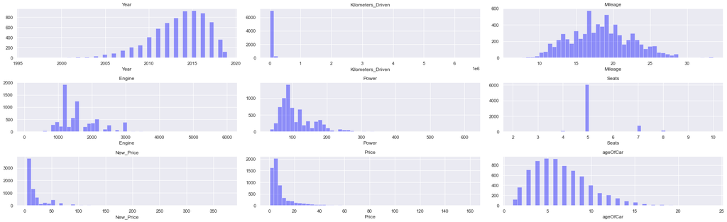

```python
# generate distplots of all numeric colums to see how the data in each column skews
plt.figure(figsize=(25,25))
numeric_columns = data.select_dtypes(include=np.number).columns.tolist()

for i, variable in enumerate(numeric_columns):
    plt.subplot(10,3,i+1)
    sns.distplot(data[variable], kde=False, color='blue')
    plt.tight_layout()
    plt.title(variable)
```

### Observations

- Year is left skewed
- Kilometers_Driven is right skewed
- Mileage is almost normally distributed
- Engine is right skewed
- Power is right skewed
- Seats is almost normally distributed
- New Price is right skewed
- Price is rirght skewed
- ageOfCar is right skewed

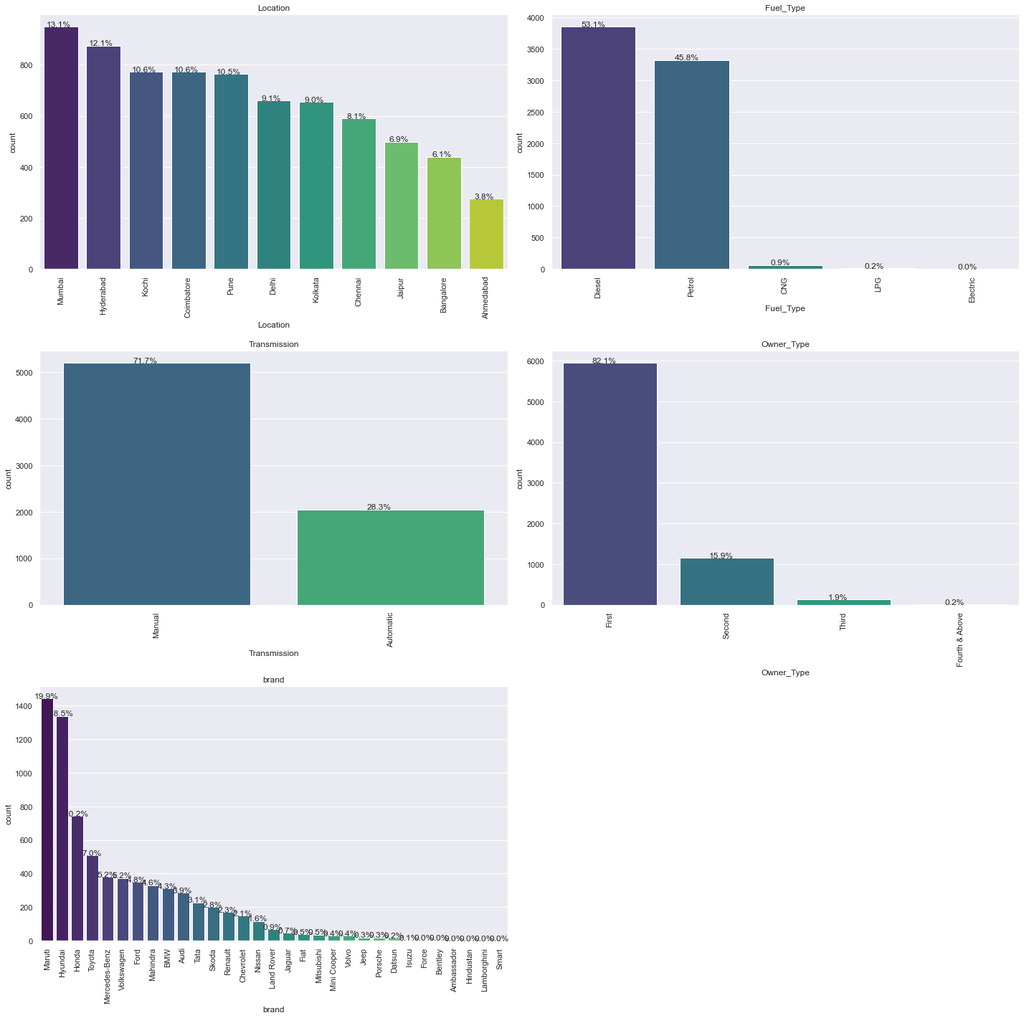

```python
# Generate countplots for all the categorical columns to visualize the categories
category_columns=['Location', 'Fuel_Type', 'Transmission', 'Owner_Type', 'brand']
plt.figure(figsize=(20,25))

for i, variable in enumerate(category_columns):
    plt.subplot(4,2,i+1)
    order = data[variable].value_counts(ascending=False).index
    ax=sns.countplot(data=data, x=data[variable], order=order, palette='viridis')
    for p in ax.patches:
        percentage = '{:.1f}%'.format(100*p.get_height()/len(data[variable]))
        x = p.get_x() + p.get_width() / 2 - 0.05
        y = p.get_y() + p.get_height()
        plt.annotate(percentage, (x,y), ha='center')
    plt.xticks(rotation=90)
    plt.tight_layout()
    plt.title(variable)
```

### Observations

- ~13% of the cars sold where in Mumbai
- ~53% of the cars sold used diesel fuel. ~45.8% used petrol, and all other methods add up to only ~1.2%
- ~71.7% of cars sold had a manual transmission
- ~82% of cars sold were sold by their first owner
- ~20% of the cars sold were made by Maruti

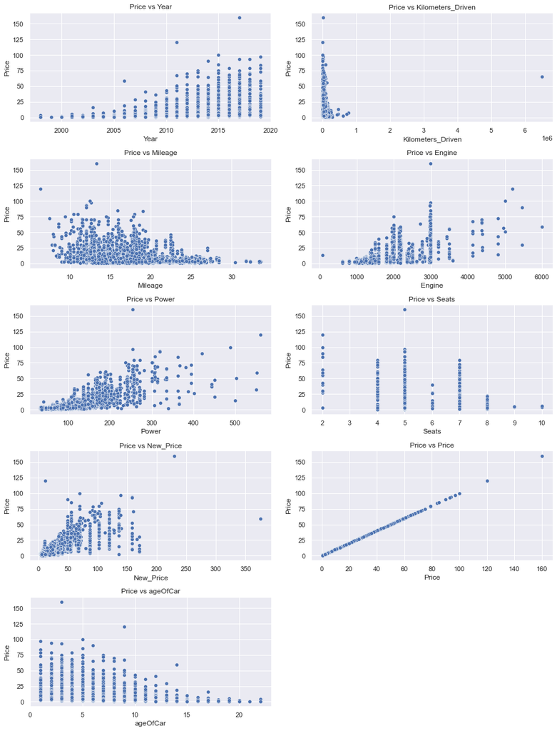

```python
# generate scatterplots for all the numberical data and how it seems to relate to price
plt.figure(figsize=(13,17))

for i, variable in enumerate(numeric_columns):
    plt.subplot(5,2,i+1)
    sns.scatterplot(x=data[variable], y=data['Price']).set(title='Price vs '+ variable)
    plt.tight_layout()
```

### Observations

- Newer cars obvioiusly cost more. the most expensive car was 3 years old
- The less a care is drive the higher the price but ther is an outlier with many more miles that still has a high relatively high price
- Higher mileage cars cost the least
- The more powerful the engine the higher the price, but there are outliers around 3000CC that command the highest price even though they are not the most powerful engine
- The most expensive cars are two and 5 seaters.

## Missing Data Handling

```python
data.isnull().sum()
```

```
Name                    0
Location                0
Year                    0
Kilometers_Driven       0
Fuel_Type               0
Transmission            0
Owner_Type              0
Mileage                83
Engine                 46
Power                 175
Seats                  54
New_Price               0
Price                1233
brand                   0
model                   0
ageOfCar                0
dtype: int64
```

```python
# Count the number of missing values per row
num_missing = data.isnull().sum(axis=1)
num_missing.value_counts()
```

```
0    5844
1    1299
2      57
3      31
4      20
5       1
dtype: int64
```

```python
# Determine how many missing values per row ther are for each variable
for n in num_missing.value_counts().sort_index().index:
    if n > 0:
        print("#"*30,f'\nFor the rows with exactly {n} missing values, NAs are found in:')
        number_missing_per_column = data[num_missing == n].isnull().sum()
        print(number_missing_per_column[number_missing_per_column > 0])
        print("\n\n")
```

```
##############################
For the rows with exactly 1 missing values, NAs are found in:
Mileage      30
Power        74
Seats         1
Price      1194
dtype: int64



##############################
For the rows with exactly 2 missing values, NAs are found in:
Mileage    35
Power      50
Seats       6
Price      23
dtype: int64



##############################
For the rows with exactly 3 missing values, NAs are found in:
Mileage     6
Engine     25
Power      30
Seats      26
Price       6
dtype: int64



##############################
For the rows with exactly 4 missing values, NAs are found in:
Mileage    11
Engine     20
Power      20
Seats      20
Price       9
dtype: int64



##############################
For the rows with exactly 5 missing values, NAs are found in:
Mileage    1
Engine     1
Power      1
Seats      1
Price      1
dtype: int64
```

### Observations

```python
columns=['Engine', 'Power', 'Mileage']
data[columns].isnull().sum()
```

```
Engine      46
Power      175
Mileage     83
dtype: int64
```

Fill in missing values by grouping name and year and fill in missing values with the median

```python
data.groupby(['Name', 'Year'])['Engine'].median().head(30)
```

```
Name                                           Year
Ambassador Classic Nova Diesel                 2003    1489.0
Audi A3 35 TDI Attraction                      2014    1968.0
Audi A3 35 TDI Premium                         2016    1968.0
Audi A3 35 TDI Premium Plus                    2015    1968.0
                                               2016    1968.0
Audi A3 35 TDI Technology                      2017    1968.0
Audi A4 1.8 TFSI                               2010    1781.0
                                               2011    1781.0
Audi A4 1.8 TFSI Technology Edition            2012    1798.0
Audi A4 2.0 TDI                                2009    1968.0
                                               2011    1968.0
                                               2012    1968.0
                                               2013    1968.0
                                               2014    1968.0
Audi A4 2.0 TDI 177 Bhp Premium Plus           2013    1968.0
                                               2014    1968.0
                                               2015    1968.0
Audi A4 2.0 TDI 177 Bhp Technology Edition     2013    1968.0
                                               2014    1968.0
Audi A4 2.0 TDI Celebration Edition            2011    1968.0
Audi A4 2.0 TDI Multitronic                    2009    1968.0
                                               2010    1968.0
                                               2011    1968.0
                                               2012    1968.0
                                               2013    1968.0
                                               2014    1968.0
                                               2015    1968.0
Audi A4 2.0 TDI Premium Sport Limited Edition  2014    1968.0
                                               2015    1968.0
Audi A4 2.0 TFSI                               2011    1984.0
Name: Engine, dtype: float64
```

```python
data['Engine']=data.groupby(['Name','Year'])['Engine'].apply(lambda x:x.fillna(x.median()))
data['Power']=data.groupby(['Name','Year'])['Power'].apply(lambda x:x.fillna(x.median()))
data['Mileage']=data.groupby(['Name','Year'])['Mileage'].apply(lambda x:x.fillna(x.median()))
data.describe().T
```

|  | count | mean | std | min | 25% | 50% | 75% | max |
| --- | --- | --- | --- | --- | --- | --- | --- | --- |
| Year | 7252.0 | 2013.366520 | 3.253162 | 1996.00 | 2011.00 | 2014.00 | 2016.0000 | 2019.00 |
| Kilometers_Driven | 7252.0 | 58700.262686 | 84433.480370 | 171.00 | 34000.00 | 53429.00 | 73000.0000 | 6500000.00 |
| Mileage | 7170.0 | 18.346332 | 4.158138 | 6.40 | 15.30 | 18.20 | 21.1000 | 33.54 |
| Engine | 7207.0 | 1616.587901 | 595.280880 | 72.00 | 1198.00 | 1493.00 | 1968.0000 | 5998.00 |
| Power | 7090.0 | 112.697657 | 53.474365 | 34.20 | 75.00 | 94.00 | 138.1000 | 616.00 |
| Seats | 7198.0 | 5.280495 | 0.809376 | 2.00 | 5.00 | 5.00 | 5.0000 | 10.00 |
| New_Price | 7252.0 | 21.308702 | 24.257701 | 3.91 | 7.88 | 11.30 | 21.6975 | 375.00 |
| Price | 6019.0 | 9.479468 | 11.187917 | 0.44 | 3.50 | 5.64 | 9.9500 | 160.00 |
| ageOfCar | 7252.0 | 6.633480 | 3.253162 | 1.00 | 4.00 | 6.00 | 9.0000 | 24.00 |

```python
data[columns].isnull().sum()
```

```
Engine      45
Power      162
Mileage     82
dtype: int64
```

```python
data.head()
```

|  | Name | Location | Year | Kilometers_Driven | Fuel_Type | Transmission | Owner_Type | Mileage | Engine | Power | Seats | New_Price | Price | brand | model | ageOfCar |
| --- | --- | --- | --- | --- | --- | --- | --- | --- | --- | --- | --- | --- | --- | --- | --- | --- |
| 0 | Maruti Wagon R LXI CNG | Mumbai | 2010 | 72000 | CNG | Manual | First | 26.60 | 998.0 | 58.16 | 5.0 | 5.51 | 1.75 | Maruti | WagonR | 10 |
| 1 | Hyundai Creta 1.6 CRDi SX Option | Pune | 2015 | 41000 | Diesel | Manual | First | 19.67 | 1582.0 | 126.20 | 5.0 | 16.06 | 12.50 | Hyundai | Creta1.6 | 5 |
| 2 | Honda Jazz V | Chennai | 2011 | 46000 | Petrol | Manual | First | 18.20 | 1199.0 | 88.70 | 5.0 | 8.61 | 4.50 | Honda | JazzV | 9 |
| 3 | Maruti Ertiga VDI | Chennai | 2012 | 87000 | Diesel | Manual | First | 20.77 | 1248.0 | 88.76 | 7.0 | 11.27 | 6.00 | Maruti | ErtigaVDI | 8 |
| 4 | Audi A4 New 2.0 TDI Multitronic | Coimbatore | 2013 | 40670 | Diesel | Automatic | Second | 15.20 | 1968.0 | 140.80 | 5.0 | 53.14 | 17.74 | Audi | A4New | 7 |

```python
data.groupby(['brand','model'])['Engine'].median().head(10)
```

```
brand       model
Ambassador  ClassicNova    1489.0
Audi        A335           1968.0
            A41.8          1781.0
            A42.0          1968.0
            A43.0          2967.0
            A43.2          3197.0
            A430           1395.0
            A435           1968.0
            A4New          1968.0
            A62.0          1968.0
Name: Engine, dtype: float64
```

```python
# use Median of the same brand and model

# Engine
data['Engine']=data.groupby(['brand','model'])['Engine'].apply(lambda x:x.fillna(x.median()))
```

```python
# Power
data['Power']=data.groupby(['brand','model'])['Power'].apply(lambda x:x.fillna(x.median()))
```

```python
# Mileage
data['Mileage']=data.groupby(['brand','model'])['Mileage'].apply(lambda x:x.fillna(x.median()))
```

```python
# Get updated numbers of missing data for these three columns
data[columns].isnull().sum()
```

```
Engine     18
Power      63
Mileage    32
dtype: int64
```

```python
data.groupby(['model','Year'])['Engine'].agg({'median','mean','max'}).sort_values(by='model', ascending='True').head(10)
```

| model | Year | mean | median | max |
| --- | --- | --- | --- | --- |
| 1000AC | 1998 | 970.000000 | 970.0 | 970.0 |
| 1Series | 2013 | 1995.000000 | 1995.0 | 1995.0 |
|  | 2015 | 1995.000000 | 1995.0 | 1995.0 |
| 370ZAT | 2012 | 3696.000000 | 3696.0 | 3696.0 |
| 3Series | 2018 | 1995.000000 | 1995.0 | 1995.0 |
|  | 2017 | 1995.000000 | 1995.0 | 1995.0 |
|  | 2016 | 1995.000000 | 1995.0 | 1995.0 |
|  | 2015 | 1995.000000 | 1995.0 | 1995.0 |
|  | 2014 | 2078.166667 | 1995.0 | 2993.0 |
|  | 2013 | 2066.428571 | 1995.0 | 2993.0 |

```python
data.groupby(['brand','Engine'])['Power'].agg({'median','mean','max'}).head(10)
```

| brand | Engine | mean | median | max |
| --- | --- | --- | --- | --- |
| Ambassador | 1489.0 | 35.500000 | 35.50 | 35.50 |
| Audi | 1395.0 | 147.510000 | 147.51 | 147.51 |
|  | 1781.0 | 163.200000 | 163.20 | 163.20 |
|  | 1798.0 | 181.033333 | 187.74 | 187.74 |
|  | 1968.0 | 167.123179 | 174.33 | 187.74 |
|  | 1984.0 | 196.022000 | 207.90 | 226.60 |
|  | 2698.0 | 179.500000 | 179.50 | 179.50 |
|  | 2773.0 | 201.000000 | 201.00 | 201.00 |
|  | 2894.0 | 444.000000 | 444.00 | 444.00 |
|  | 2967.0 | 241.740000 | 241.40 | 246.70 |

```python
data['Seats'].isnull().sum()
```

```
54
```

Grouping by model as the number of seats for the same car, even if different years should be very close to accuate

```python
data['Seats']=data.groupby(['model'])['Seats'].apply(lambda x:x.fillna(x.median()))
```

```python
data['Seats'].isnull().sum()
```

```
23
```

```python
data[data['Seats'].isnull()==True].head(10)
```

|  | Name | Location | Year | Kilometers_Driven | Fuel_Type | Transmission | Owner_Type | Mileage | Engine | Power | Seats | New_Price | Price | brand | model | ageOfCar |
| --- | --- | --- | --- | --- | --- | --- | --- | --- | --- | --- | --- | --- | --- | --- | --- | --- |
| 208 | Maruti Swift 1.3 VXi | Kolkata | 2010 | 42001 | Petrol | Manual | First | 16.1 | NaN | NaN | NaN | 7.88 | 2.11 | Maruti | Swift1.3 | 10 |
| 733 | Maruti Swift 1.3 VXi | Chennai | 2006 | 97800 | Petrol | Manual | Third | 16.1 | NaN | NaN | NaN | 7.88 | 1.75 | Maruti | Swift1.3 | 14 |
| 1327 | Maruti Swift 1.3 ZXI | Hyderabad | 2015 | 50295 | Petrol | Manual | First | 16.1 | NaN | NaN | NaN | 7.88 | 5.80 | Maruti | Swift1.3 | 5 |
| 2074 | Maruti Swift 1.3 LXI | Pune | 2011 | 24255 | Petrol | Manual | First | 16.1 | NaN | NaN | NaN | 7.88 | 3.15 | Maruti | Swift1.3 | 9 |
| 2325 | Maruti Swift 1.3 VXI ABS | Pune | 2015 | 67000 | Petrol | Manual | First | 16.1 | NaN | NaN | NaN | 7.88 | 4.70 | Maruti | Swift1.3 | 5 |
| 2335 | Maruti Swift 1.3 VXi | Mumbai | 2007 | 55000 | Petrol | Manual | Second | 16.1 | NaN | NaN | NaN | 7.88 | 1.75 | Maruti | Swift1.3 | 13 |
| 2369 | Maruti Estilo LXI | Chennai | 2008 | 56000 | Petrol | Manual | Second | 19.5 | 1061.0 | NaN | NaN | 7.88 | 1.50 | Maruti | EstiloLXI | 12 |
| 2668 | Maruti Swift 1.3 VXi | Kolkata | 2014 | 32986 | Petrol | Manual | First | 16.1 | NaN | NaN | NaN | 7.88 | 4.24 | Maruti | Swift1.3 | 6 |
| 3404 | Maruti Swift 1.3 VXi | Jaipur | 2006 | 125000 | Petrol | Manual | Fourth & Above | 16.1 | NaN | NaN | NaN | 7.88 | 2.35 | Maruti | Swift1.3 | 14 |
| 3810 | Honda CR-V AT With Sun Roof | Kolkata | 2013 | 27000 | Petrol | Automatic | First | 14.0 | NaN | NaN | NaN | 33.51 | 11.99 | Honda | CR-VAT | 7 |

```python
# since most of the data on the cars shows that 5 seats is most common,
# we will set the final 23 missing Seats values to be 5
data['Seats']=data['Seats'].fillna(5)
```

```python
data['Seats'].isnull().sum()
```

```
0
```

```python
# Make Location and brand category types
data["Location"] = data["Location"].astype("category")
data["brand"] = data["brand"].astype("category")
```

```python
data.isnull().sum()
```

```
Name                    0
Location                0
Year                    0
Kilometers_Driven       0
Fuel_Type               0
Transmission            0
Owner_Type              0
Mileage                32
Engine                 18
Power                  63
Seats                   0
New_Price               0
Price                1233
brand                   0
model                   0
ageOfCar                0
dtype: int64
```

```python
colFill = ["Power", "Engine", "Mileage"]

for i in colFill:
    data[i] = data[i].fillna(data[i].median())
```

```python
# This next command removed any rows that still have missing data.
# The result is 1,233 rows will be dropped becuase the used car sales price was not provided.
# This represents a loss of ~17% of the total data available

data.dropna(inplace=True, axis=0)
```

```python
data.isnull().sum()
```

```
Name                 0
Location             0
Year                 0
Kilometers_Driven    0
Fuel_Type            0
Transmission         0
Owner_Type           0
Mileage              0
Engine               0
Power                0
Seats                0
New_Price            0
Price                0
brand                0
model                0
ageOfCar             0
dtype: int64
```

## Analysis

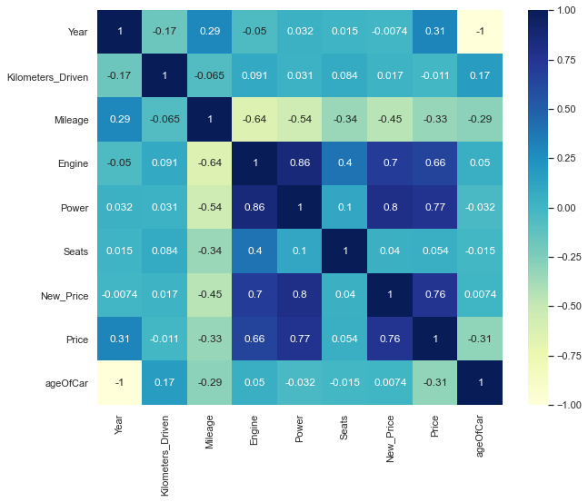

```python
plt.figure(figsize=(10,8))
sns.heatmap(data.corr(), annot=True, cmap="YlGnBu")
plt.show()
```

### Observations

- Engine and Power are strongly correlated (as might be expected) (.86)
- Mileage has a negative correlation to Engine, Power, Price and ageOfCar
- Price has a positive correlation to Engine, Power, Seats, & New_Price (the more expenive a car is new the more likely that it will be more expesive being sold used
- Kilometers_Driven is the least correlated to price (-0.011)

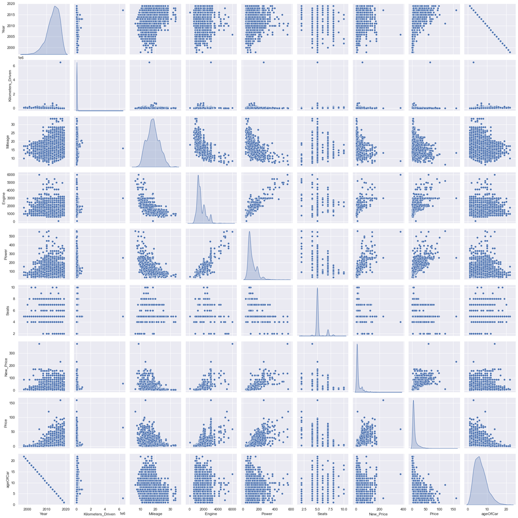

```python
sns.pairplot(data=data, diag_kind="kde")
plt.show()
```

### Correlations to Price

#### Price Vs Seat

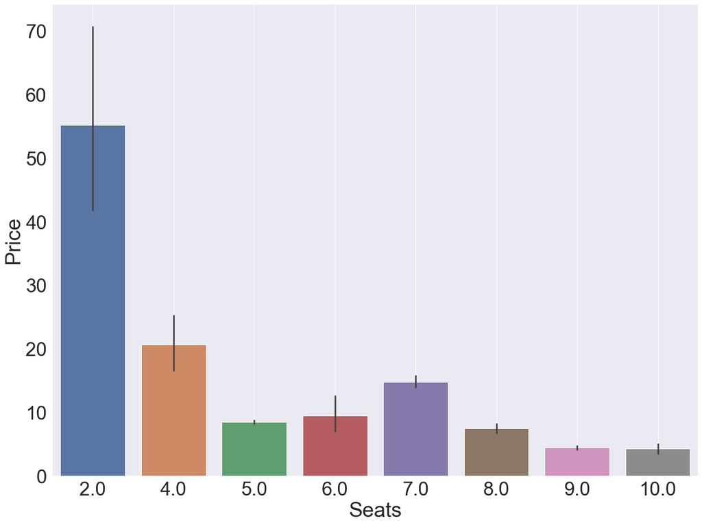

```python
plt.figure(figsize=(20,15))
sns.set(font_scale=3)
sns.barplot(data=data, x='Seats', y='Price')
plt.grid();
```

#### Price Vs Location

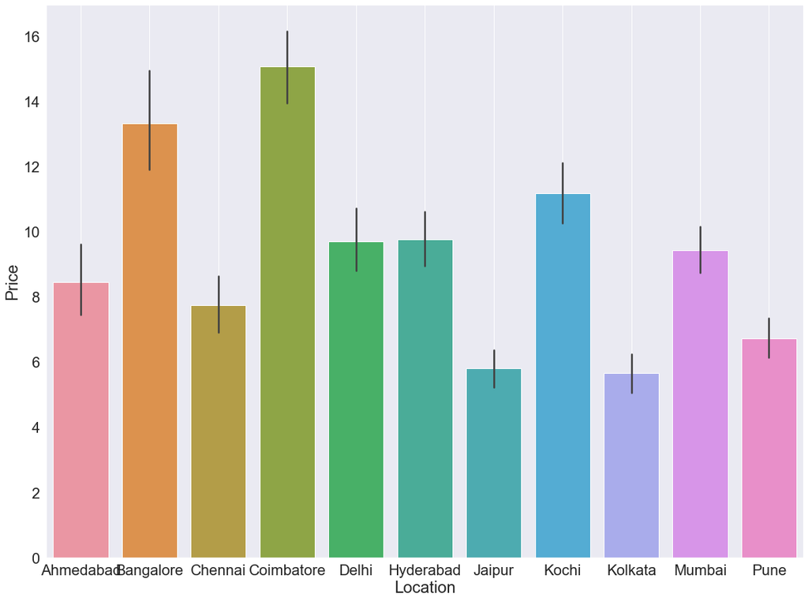

```python
plt.figure(figsize=(20,15))
sns.set(font_scale=2)
sns.barplot(data=data, x='Location', y='Price')
plt.grid();
```

#### Price Vs Brand

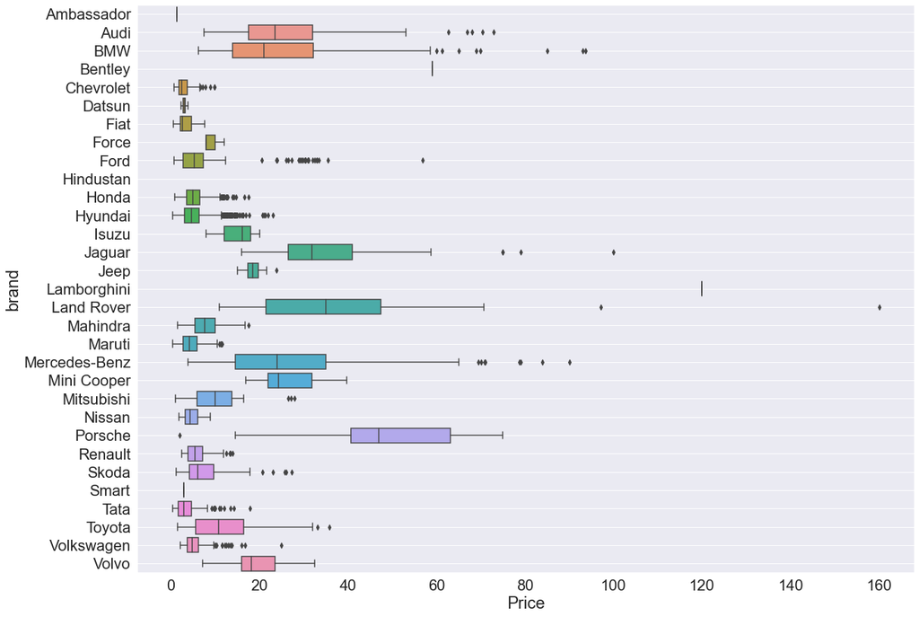

```python
plt.figure(figsize=(20,15))
sns.set(font_scale=2)
sns.boxplot(data=data, x='Price', y='brand')
plt.grid();
```

#### Price Vs Engine Vs Transmission

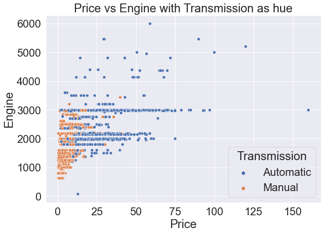

```python
plt.figure(figsize=(10,7))
plt.title('Price vs Engine with Transmission as hue')
sns.scatterplot(data=data, x='Price', y='Engine', hue='Transmission');
```

#### Price Vs Power Vs Transmission

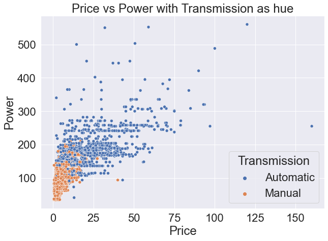

```python
plt.figure(figsize=(10,7))
plt.title('Price vs Power with Transmission as hue')
sns.scatterplot(data=data, x='Price', y='Power', hue='Transmission');
```

#### Price Vs Mileage Vs Transmission

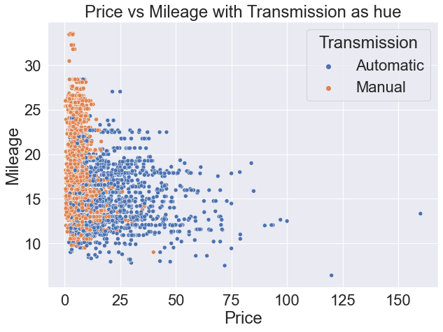

```python
plt.figure(figsize=(10,7))
plt.title('Price vs Mileage with Transmission as hue')
sns.scatterplot(data=data, x='Price', y='Mileage', hue='Transmission');
```

#### Price Vs Year Vs Transmission

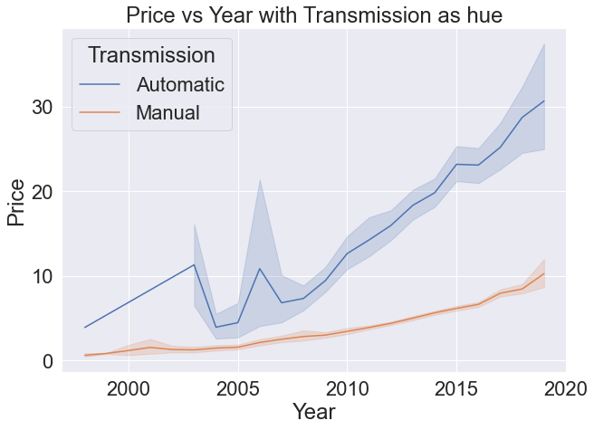

```python
plt.figure(figsize=(10,7))
plt.title('Price vs Year with Transmission as hue')
sns.lineplot(data=data, x='Year', y='Price', hue='Transmission');
```

#### Price Vs Year Vs Fuel Type

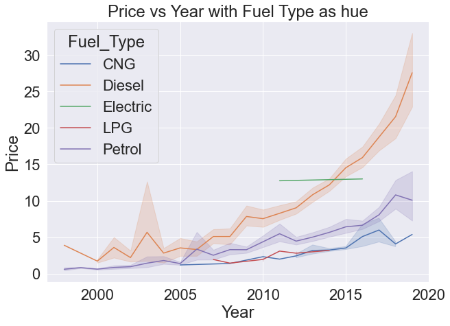

```python
plt.figure(figsize=(10,7))
plt.title('Price vs Year with Fuel Type as hue')
sns.lineplot(data=data, x='Year', y='Price', hue='Fuel_Type');
```

```python
#### Price Vs Mileage Vs Fuel_Type
```

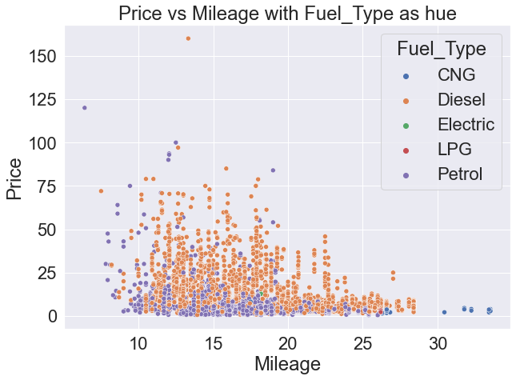

```python
plt.figure(figsize=(10,7))
plt.title('Price vs Mileage with Fuel_Type as hue')
sns.scatterplot(data=data, x='Mileage', y='Price', hue='Fuel_Type');
```

## Transform Data to reach Normal Distribution

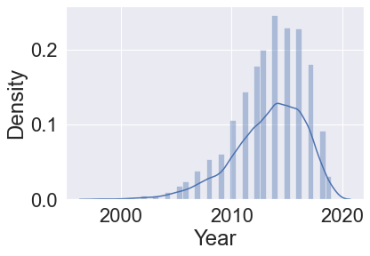

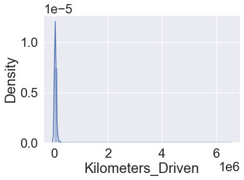

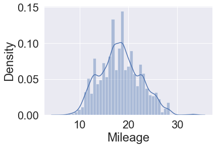

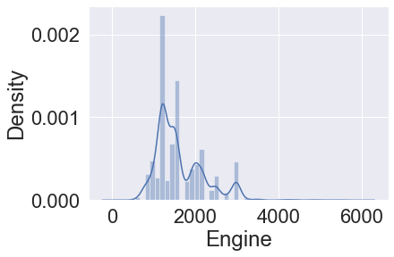

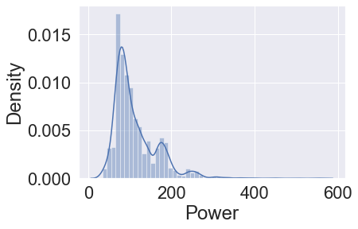

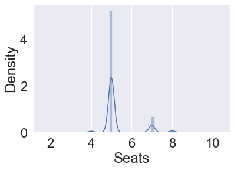

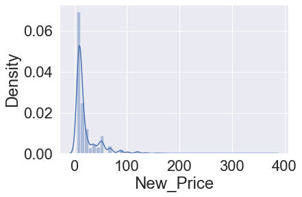

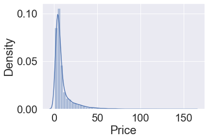

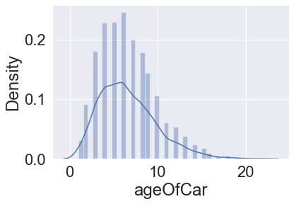

```python
cols_to_log = data.select_dtypes(include=np.number).columns.tolist()
for columnName in cols_to_log:
    sns.distplot(data[columnName], kde=True)
    plt.show();
```

Many of the charts show that they are right skewed. Year is left skewed and Mileage is close to normal distribuiton

```python
log_trans(data, ['Kilometers_Driven','Price'])
```

```
<class 'pandas.core.frame.DataFrame'>
Int64Index: 6019 entries, 0 to 6018
Data columns (total 18 columns):
 #   Column                 Non-Null Count  Dtype
---  ------                 --------------  -----
 0   Name                   6019 non-null   object
 1   Location               6019 non-null   category
 2   Year                   6019 non-null   int64
 3   Kilometers_Driven      6019 non-null   int64
 4   Fuel_Type              6019 non-null   category
 5   Transmission           6019 non-null   category
 6   Owner_Type             6019 non-null   category
 7   Mileage                6019 non-null   float64
 8   Engine                 6019 non-null   float64
 9   Power                  6019 non-null   float64
 10  Seats                  6019 non-null   float64
 11  New_Price              6019 non-null   float64
 12  Price                  6019 non-null   float64
 13  brand                  6019 non-null   category
 14  model                  6019 non-null   object
 15  ageOfCar               6019 non-null   int64
 16  Kilometers_Driven_log  6019 non-null   float64
 17  Price_log              6019 non-null   float64
dtypes: category(5), float64(8), int64(3), object(2)
memory usage: 819.0+ KB
```

```python
# Dropping all non numneric data before putting the data through the model
data.drop(['Name', 'Year', 'model', 'brand'],axis=1,inplace=True)
```

```python
data.info()
```

```
<class 'pandas.core.frame.DataFrame'>
Int64Index: 6019 entries, 0 to 6018
Data columns (total 14 columns):
 #   Column                 Non-Null Count  Dtype
---  ------                 --------------  -----
 0   Location               6019 non-null   category
 1   Kilometers_Driven      6019 non-null   int64
 2   Fuel_Type              6019 non-null   category
 3   Transmission           6019 non-null   category
 4   Owner_Type             6019 non-null   category
 5   Mileage                6019 non-null   float64
 6   Engine                 6019 non-null   float64
 7   Power                  6019 non-null   float64
 8   Seats                  6019 non-null   float64
 9   New_Price              6019 non-null   float64
 10  Price                  6019 non-null   float64
 11  ageOfCar               6019 non-null   int64
 12  Kilometers_Driven_log  6019 non-null   float64
 13  Price_log              6019 non-null   float64
dtypes: category(4), float64(8), int64(2)
memory usage: 670.7 KB
```

## Building the Model

```python
X = data.drop(["Price", "Price_log"], axis=1)
y = data[["Price_log", "Price"]]
```

```python
X = encode_cat_variables(X)
X.head()
```

|  | Kilometers_Driven | Mileage | Engine | Power | Seats | New_Price | ageOfCar | Kilometers_Driven_log | Location_Bangalore | Location_Chennai | Location_Coimbatore | Location_Delhi | Location_Hyderabad | Location_Jaipur | Location_Kochi | Location_Kolkata | Location_Mumbai | Location_Pune | Fuel_Type_Diesel | Fuel_Type_Electric | Fuel_Type_LPG | Fuel_Type_Petrol | Transmission_Manual | Owner_Type_Fourth & Above | Owner_Type_Second | Owner_Type_Third |
| --- | --- | --- | --- | --- | --- | --- | --- | --- | --- | --- | --- | --- | --- | --- | --- | --- | --- | --- | --- | --- | --- | --- | --- | --- | --- | --- |
| 0 | 72000 | 26.60 | 998.0 | 58.16 | 5.0 | 5.51 | 10 | 11.184421 | 0 | 0 | 0 | 0 | 0 | 0 | 0 | 0 | 1 | 0 | 0 | 0 | 0 | 0 | 1 | 0 | 0 | 0 |
| 1 | 41000 | 19.67 | 1582.0 | 126.20 | 5.0 | 16.06 | 5 | 10.621327 | 0 | 0 | 0 | 0 | 0 | 0 | 0 | 0 | 0 | 1 | 1 | 0 | 0 | 0 | 1 | 0 | 0 | 0 |
| 2 | 46000 | 18.20 | 1199.0 | 88.70 | 5.0 | 8.61 | 9 | 10.736397 | 0 | 1 | 0 | 0 | 0 | 0 | 0 | 0 | 0 | 0 | 0 | 0 | 0 | 1 | 1 | 0 | 0 | 0 |
| 3 | 87000 | 20.77 | 1248.0 | 88.76 | 7.0 | 11.27 | 8 | 11.373663 | 0 | 1 | 0 | 0 | 0 | 0 | 0 | 0 | 0 | 0 | 1 | 0 | 0 | 0 | 1 | 0 | 0 | 0 |
| 4 | 40670 | 15.20 | 1968.0 | 140.80 | 5.0 | 53.14 | 7 | 10.613246 | 0 | 0 | 1 | 0 | 0 | 0 | 0 | 0 | 0 | 0 | 1 | 0 | 0 | 0 | 0 | 0 | 1 | 0 |

```python
X_train, X_test, y_train, y_test = train_test_split(X, y, test_size=0.3, random_state=28)
X_train.reset_index()
print("X_train:", X_train.shape)
print(" X_test:", X_test.shape)
print("y_train:", y_train.shape)
print(" y_test:", y_test.shape)
```

```
X_train: (4213, 26)
 X_test: (1806, 26)
y_train: (4213, 2)
 y_test: (1806, 2)
```

```python
# Add a constant explicitly to the X_train and X_Test data
X_train = sm.add_constant(X_train)
X_test = sm.add_constant(X_test)
```

```python
olsmodel1 = build_ols_model(X_train)
print(olsmodel1.summary())
```

```
                            OLS Regression Results
==============================================================================
Dep. Variable:              Price_log   R-squared:                       0.896
Model:                            OLS   Adj. R-squared:                  0.896
Method:                 Least Squares   F-statistic:                     1394.
Date:                Sat, 02 Apr 2022   Prob (F-statistic):               0.00
Time:                        04:19:40   Log-Likelihood:                -687.01
No. Observations:                4213   AIC:                             1428.
Df Residuals:                    4186   BIC:                             1599.
Df Model:                          26
Covariance Type:            nonrobust
=============================================================================================
                                coef    std err          t      P>|t|      [0.025      0.975]
---------------------------------------------------------------------------------------------
const                         2.8418      0.145     19.618      0.000       2.558       3.126
Kilometers_Driven          -2.11e-07   1.91e-07     -1.106      0.269   -5.85e-07    1.63e-07
Mileage                      -0.0210      0.002    -11.074      0.000      -0.025      -0.017
Engine                        0.0001   2.12e-05      5.268      0.000    7.01e-05       0.000
Power                         0.0052      0.000     23.317      0.000       0.005       0.006
Seats                         0.0099      0.007      1.340      0.180      -0.005       0.024
New_Price                     0.0073      0.000     23.322      0.000       0.007       0.008
ageOfCar                     -0.1180      0.002    -60.898      0.000      -0.122      -0.114
Kilometers_Driven_log        -0.0596      0.011     -5.315      0.000      -0.082      -0.038
Location_Bangalore            0.1300      0.029      4.407      0.000       0.072       0.188
Location_Chennai             -0.0104      0.028     -0.373      0.709      -0.065       0.044
Location_Coimbatore           0.0468      0.027      1.725      0.085      -0.006       0.100
Location_Delhi               -0.0747      0.027     -2.728      0.006      -0.128      -0.021
Location_Hyderabad            0.0769      0.026      2.915      0.004       0.025       0.129
Location_Jaipur              -0.1023      0.029     -3.504      0.000      -0.159      -0.045
Location_Kochi               -0.0586      0.027     -2.170      0.030      -0.112      -0.006
Location_Kolkata             -0.2682      0.028     -9.687      0.000      -0.322      -0.214
Location_Mumbai              -0.0628      0.026     -2.384      0.017      -0.114      -0.011
Location_Pune                -0.0812      0.027     -3.002      0.003      -0.134      -0.028
Fuel_Type_Diesel              0.2021      0.051      3.955      0.000       0.102       0.302
Fuel_Type_Electric            0.9613      0.209      4.595      0.000       0.551       1.371
Fuel_Type_LPG                -0.1921      0.139     -1.386      0.166      -0.464       0.080
Fuel_Type_Petrol             -0.1170      0.052     -2.245      0.025      -0.219      -0.015
Transmission_Manual          -0.2416      0.014    -17.725      0.000      -0.268      -0.215
Owner_Type_Fourth & Above     0.1094      0.096      1.134      0.257      -0.080       0.298
Owner_Type_Second            -0.0909      0.013     -7.098      0.000      -0.116      -0.066
Owner_Type_Third             -0.1654      0.034     -4.812      0.000      -0.233      -0.098
==============================================================================
Omnibus:                     1694.468   Durbin-Watson:                   1.916
Prob(Omnibus):                  0.000   Jarque-Bera (JB):            37620.310
Skew:                          -1.388   Prob(JB):                         0.00
Kurtosis:                      17.374   Cond. No.                     3.39e+06
==============================================================================

Notes:
[1] Standard Errors assume that the covariance matrix of the errors is correctly specified.
[2] The condition number is large, 3.39e+06. This might indicate that there are
strong multicollinearity or other numerical problems.
```

### Observations

- Both R-squared and Adj R-squared in our model are quite high (0.896). This tells us that the model is able to explain variance in proce of used cars for up to 89%
- There doesn't seem to be any under or overfitting

```python
## Performance Test
model_perf(olsmodel1, X_train, X_test)
```

```
    Data       RMSE       MAE       MAPE
0  Train  12.384405  2.424736  23.629964
1   Test   4.545561  1.945814  20.719002
```

### Observations

- Root Mean Squared Error of traing and Test data is very different (12.38 vs 4.54) suggesting that the model is underfitting of the data
- Mean Absolute Error indicates that our current model is able to predict used car prices within mean error of 1.94 lakhs on test data
- Mean Absolute Percentage Error is ~21% on the test data